# 431 Class 09

Thomas E. Love, Ph.D.

2025-09-30

## Today’s Agenda

- New Data, with Missing Values
  - Using `naniar` to help identify missingness
- More on One-Factor Analysis of Variance (ANOVA)
  - Pairwise comparisons of means
    - Getting actual simultaneous confidence intervals
    - Bonferroni and Tukey HSD procedures
  - Considering an Outcome Transformation
- Favorite Movies: Session 2

## Load packages and set theme

```r
library(janitor)
library(DescTools)  ## NEW - for Bonferroni and Tukey HSD CIs
library(naniar)     ## dealing with missing data
library(car)        ## for the Box-Cox plot
library(patchwork)
library(rstanarm)
library(easystats)
library(tidyverse)

theme_set(theme_lucid()) ## new theme for ggplots!
knitr::opts_chunk$set(comment = NA)

source("c09/data/Love-431.R") # for the lovedist() function
```

- See [Class 09 README](https://github.com/THOMASELOVE/431-classes-2025/blob/main/class09/README.md) for alternative ggplot themes.

## Get the data

[EUROFAMCARE project](https://www.uke.de/extern/eurofamcare/): a survey on the situation of family carers of older people in Europe.

```r
ecare_orig <- read_csv("c09/data/eurocare.csv", show_col_types = FALSE) |>
  janitor::clean_names() |>
  mutate(across(where(is.character), as_factor)) |>
  mutate(subject = as.character(subject))

dim(ecare_orig)
```

```
[1] 902  14
```

```r
names(ecare_orig)
```

```
 [1] "subject"     "hours"       "relation"    "e_sex"       "e_age"
 [6] "dependency"  "barthel"     "c_age"       "c_sex"       "c_education"
[11] "c_employed"  "neg_impact"  "pos_impact"  "qof_life"
```

## Missingness?

```r
miss_var_summary(ecare_orig)
```

```
# A tibble: 14 × 3
   variable    n_miss pct_miss
   <chr>        <int>    <num>
 1 c_education     60    6.65
 2 pos_impact      21    2.33
 3 barthel         19    2.11
 4 e_age           11    1.22
 5 neg_impact      10    1.11
 6 qof_life         5    0.554
 7 relation         1    0.111
 8 e_sex            1    0.111
 9 dependency       1    0.111
10 c_age            1    0.111
11 c_sex            1    0.111
12 subject          0    0
13 hours            0    0
14 c_employed       0    0
```

## Today’s Variables

```r
ecare_new <- ecare_orig |>
  dplyr::select(subject, hours, c_education, pos_impact, dependency)

data_codebook(ecare_new |> select(!subject))
```

```
select(ecare_new, !subject) (902 rows and 4 variables, 4 shown)

ID | Name        | Type        |  Missings |      Values |           N
---+-------------+-------------+-----------+-------------+------------
1  | hours       | numeric     |  0 (0.0%) |    [4, 168] |         902
---+-------------+-------------+-----------+-------------+------------
2  | c_education | categorical | 60 (6.7%) |      Middle | 506 (60.1%)
   |             |             |           |         Low | 180 (21.4%)
   |             |             |           |        High | 156 (18.5%)
---+-------------+-------------+-----------+-------------+------------
3  | pos_impact  | numeric     | 21 (2.3%) |     [5, 16] |         881
---+-------------+-------------+-----------+-------------+------------
4  | dependency  | categorical |  1 (0.1%) |    moderate | 306 (34.0%)
   |             |             |           |      severe | 304 (33.7%)
   |             |             |           | independent |  66 ( 7.3%)
   |             |             |           |      slight | 225 (25.0%)
----------------------------------------------------------------------
```

## Put factors in sensible orders?

```r
ecare_new <- ecare_new |>
  mutate(c_education = fct_relevel(c_education, "High",
                                   "Middle", "Low"),
         dependency = fct_relevel(dependency, "independent", "slight",
                                  "moderate", "severe"))

ecare_new |> tabyl(c_education, dependency)
```

```
 c_education independent slight moderate severe NA_
        High           5     39       62     50   0
      Middle          45    135      163    163   0
         Low          12     42       61     65   0
        <NA>           4      9       20     26   1
```

## Do mean `hours` vary by `c_education`?

```r
ggplot(ecare_new, aes(y = hours, x = c_education)) +
  geom_violin(aes(fill = c_education)) +
  geom_boxplot(width = 0.2) +
  stat_summary(fun = mean, geom = "point",
               shape = 16, size = 3, col = "red") +
  scale_fill_viridis_d(alpha = 0.3) +
  guides(fill = "none")
```

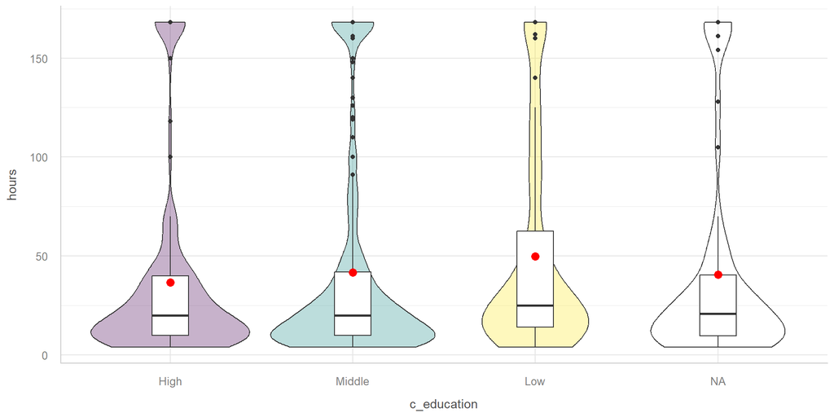

## Try again with complete cases?

```r
ecare_1 <- ecare_new |>
  filter(complete.cases(hours, c_education))
dim(ecare_1)
```

```
[1] 842   5
```

```r
ggplot(ecare_1, aes(y = hours, x = c_education)) +
  geom_violin(aes(fill = c_education)) +
  geom_boxplot(width = 0.2) +
  stat_summary(fun = mean, geom = "point",
               shape = 16, size = 3, col = "red") +
  scale_fill_viridis_d(alpha = 0.3) +
  guides(fill = "none")
```

## Try again with complete cases?

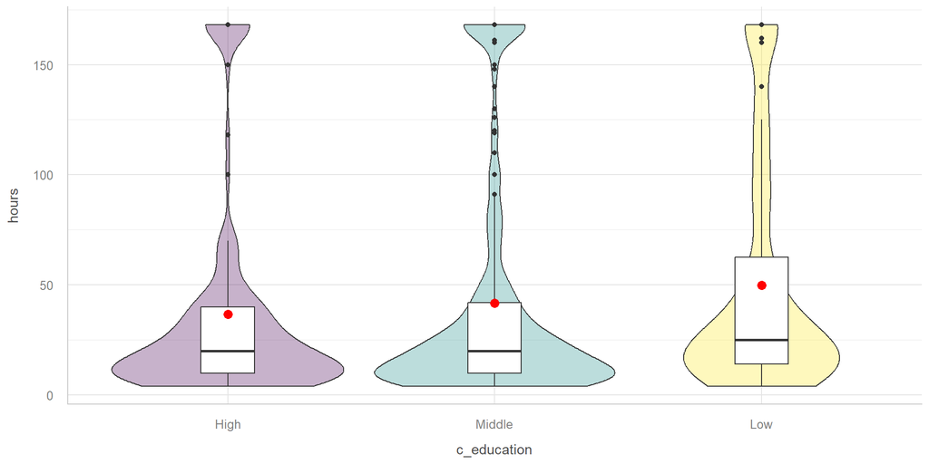

## Do `hours` vary by `c_education`? (1/2)

```r
ecare_1 |> group_by(c_education) |> reframe(lovedist(hours))
```

```
# A tibble: 3 × 11
  c_education     n  miss  mean    sd   med   mad   min   q25   q75   max
  <fct>       <int> <int> <dbl> <dbl> <dbl> <dbl> <dbl> <dbl> <dbl> <dbl>
1 High          156     0  36.6  46.4    20  17.8     4    10  40     168
2 Middle        506     0  41.8  51.4    20  19.3     4    10  42     168
3 Low           180     0  49.8  52.2    25  22.2     4    14  62.5   168
```

- Sample mean `hours` are somewhat smaller for carers with higher levels of education.
  - Does these mean differences seem meaningful?
  - Does each group’s data follow a Normal distribution?

## Do `hours` vary by `c_education`? (2/2)

```r
ecare_1 |> group_by(c_education) |> reframe(lovedist(hours))
```

```
# A tibble: 3 × 11
  c_education     n  miss  mean    sd   med   mad   min   q25   q75   max
  <fct>       <int> <int> <dbl> <dbl> <dbl> <dbl> <dbl> <dbl> <dbl> <dbl>
1 High          156     0  36.6  46.4    20  17.8     4    10  40     168
2 Middle        506     0  41.8  51.4    20  19.3     4    10  42     168
3 Low           180     0  49.8  52.2    25  22.2     4    14  62.5   168
```

- What else might we consider here?
  - Do we have a balanced design?
  - Are sample variances very different from each other?

## ANOVA model for this comparison

```r
m1 <- lm(hours ~ c_education, data = ecare_1)
anova(m1)
```

```
Analysis of Variance Table

Response: hours
             Df  Sum Sq Mean Sq F value  Pr(>F)
c_education   2   15301  7650.4  2.9758 0.05155 .
Residuals   839 2156977  2570.9
---
Signif. codes:  0 '***' 0.001 '**' 0.01 '*' 0.05 '.' 0.1 ' ' 1
```

```r
model_parameters(m1, ci = 0.95)
```

```
Parameter            | Coefficient |   SE |         95% CI | t(839) |      p
----------------------------------------------------------------------------
(Intercept)          |       36.62 | 4.06 | [28.65, 44.58] |   9.02 | < .001
c education [Middle] |        5.14 | 4.64 | [-3.97, 14.26] |   1.11 | 0.268
c education [Low]    |       13.20 | 5.55 | [ 2.31, 24.08] |   2.38 | 0.018
```

## Holm 95% pairwise comparisons??

```r
estimate_contrasts(m1, ci = 0.95, p_adjust = "holm")
```

```
Marginal Contrasts Analysis

Level1 | Level2 | Difference |   SE |         95% CI | t(839) |     p
---------------------------------------------------------------------
Middle | High   |       5.14 | 4.64 | [-3.97, 14.26] |   1.11 | 0.268
Low    | High   |      13.20 | 5.55 | [ 2.31, 24.08] |   2.38 | 0.053
Low    | Middle |       8.05 | 4.40 | [-0.58, 16.69] |   1.83 | 0.135

Variable predicted: hours
Predictors contrasted: c_education
p-value adjustment method: Holm (1979)
```

## Bonferroni approach?

```r
estimate_contrasts(m1, ci = 0.95, p_adjust = "bonferroni")
```

```
Marginal Contrasts Analysis

Level1 | Level2 | Difference |   SE |         95% CI | t(839) |     p
---------------------------------------------------------------------
Middle | High   |       5.14 | 4.64 | [-3.97, 14.26] |   1.11 | 0.805
Low    | High   |      13.20 | 5.55 | [ 2.31, 24.08] |   2.38 | 0.053
Low    | Middle |       8.05 | 4.40 | [-0.58, 16.69] |   1.83 | 0.203

Variable predicted: hours
Predictors contrasted: c_education
p-value adjustment method: Bonferroni
```

- Again, only the *p* values change here… what to do?

## Actual Bonferroni 95% CIs?

```r
## this requires library(DescTools)

PostHocTest(aov(m1), method = "bonferroni",
            conf.level = 0.95, ordered = FALSE)
```

```
  Posthoc multiple comparisons of means : Bonferroni
    95% family-wise confidence level

$c_education
                 diff     lwr.ci   upr.ci   pval
Middle-High  5.143509 -5.9949619 16.28198 0.8049
Low-High    13.195726 -0.1089773 26.50043 0.0527 .
Low-Middle   8.052218 -2.5034246 18.60786 0.2029

---
Signif. codes:  0 '***' 0.001 '**' 0.01 '*' 0.05 '.' 0.1 ' ' 1
```

## Plot means with Bonferroni CIs

```r
par(mar=c(3,10,3,3), las = 1)
plot(PostHocTest(aov(m1), method = "bonferroni", conf.level = 0.95))
```

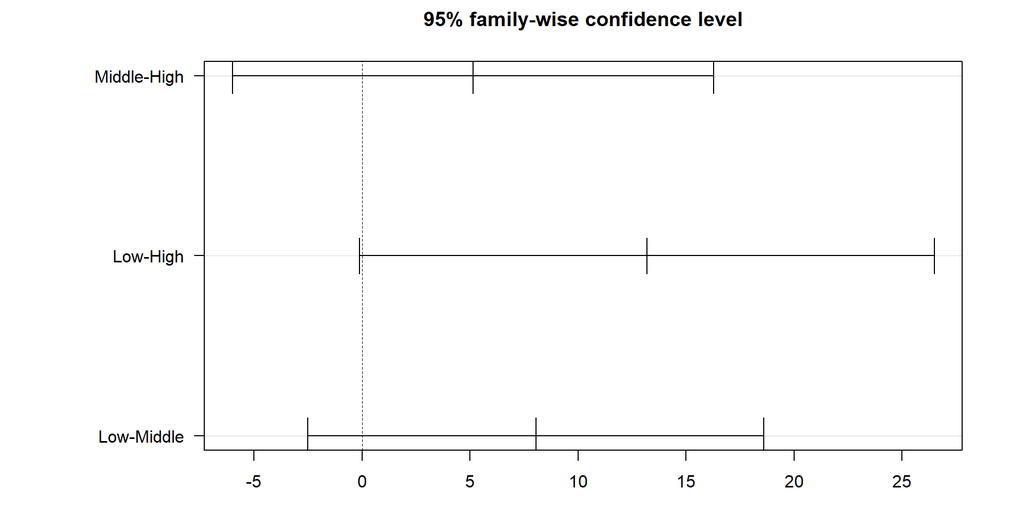

## What about Tukey HSD intervals?

Tukey’s HSD approach is a better choice than Holm for **pre-planned comparisons** with a **balanced (or nearly balanced)** design. Which should we use here?

```r
PostHocTest(aov(m1), method = "hsd", conf.level = 0.95, ordered = TRUE)
```

```
  Posthoc multiple comparisons of means : Tukey HSD
    95% family-wise confidence level
    factor levels have been ordered

$c_education
                 diff     lwr.ci   upr.ci   pval
Middle-High  5.143509 -5.7585415 16.04556 0.5096
Low-High    13.195726  0.1734226 26.21803 0.0462 *
Low-Middle   8.052218 -2.2793751 18.38381 0.1605

---
Signif. codes:  0 '***' 0.001 '**' 0.01 '*' 0.05 '.' 0.1 ' ' 1
```

## Plot means with Tukey CIs

```r
par(mar=c(3,10,3,3), las = 1)
plot(PostHocTest(aov(m1), method = "hsd", conf.level = 0.95))
```

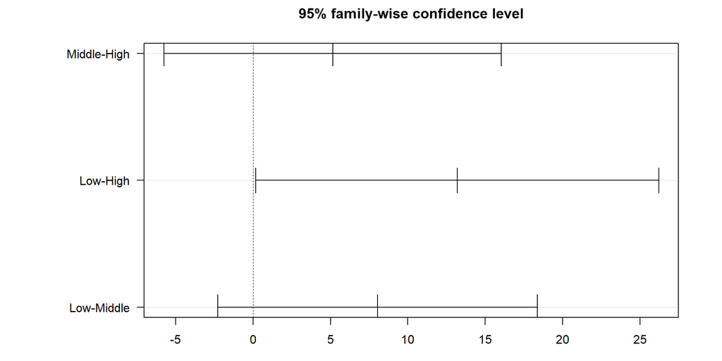

## Does model `m1` work well?

```r
plot(m1, which = 2)
```

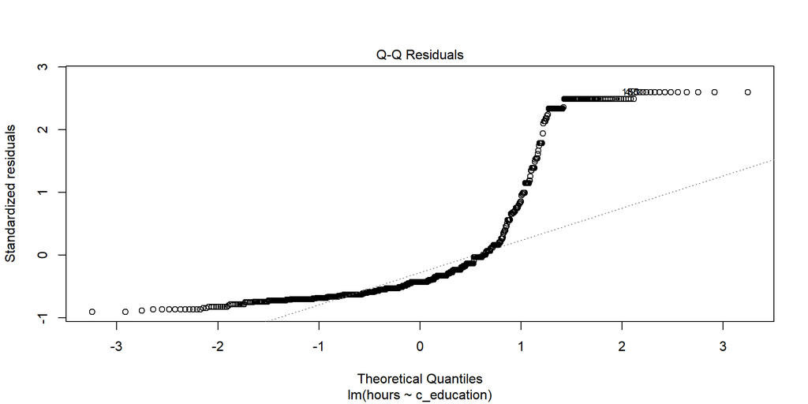

## Could we transform the outcome?

```r
boxCox(m1)
```

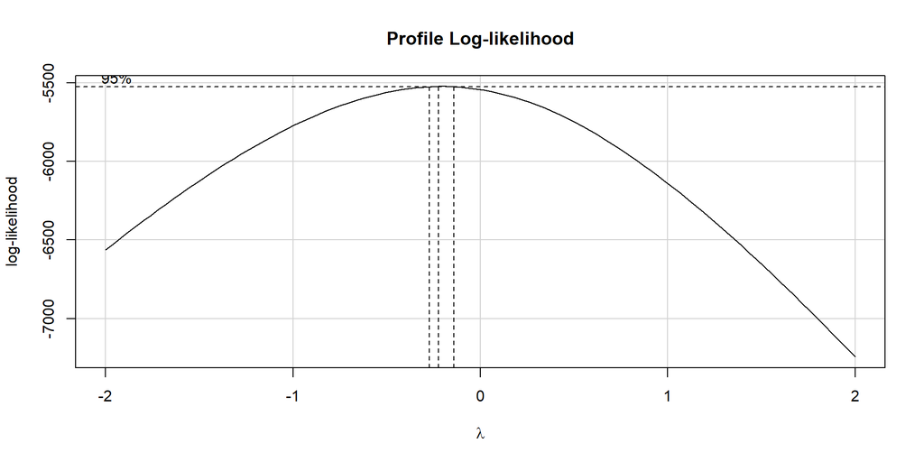

## Impact of log transformation

```r
ecare_1 |> group_by(c_education) |> reframe(lovedist(log(hours)))
```

```
# A tibble: 3 × 11
  c_education     n  miss  mean    sd   med   mad   min   q25   q75   max
  <fct>       <int> <int> <dbl> <dbl> <dbl> <dbl> <dbl> <dbl> <dbl> <dbl>
1 High          156     0  3.04  1.01  3.00  1.03  1.39  2.30  3.69  5.12
2 Middle        506     0  3.10  1.09  3.00  1.03  1.39  2.30  3.74  5.12
3 Low           180     0  3.38  1.04  3.22  1.09  1.39  2.64  4.13  5.12
```

```r
ggplot(ecare_1, aes(y = log(hours), x = c_education)) +
  geom_violin(aes(fill = c_education)) +
  geom_boxplot(width = 0.2) +
  stat_summary(fun = mean, geom = "point",
               shape = 16, size = 3, col = "red") +
  scale_fill_viridis_d(alpha = 0.3) +
  guides(fill = "none")
```

## Impact of log transformation

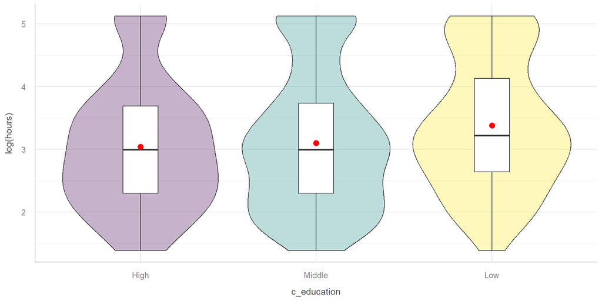

## ANOVA after Transforming `hours`

```r
m2 <- lm(log(hours) ~ c_education, data = ecare_1)

anova(m2)
```

```
Analysis of Variance Table

Response: log(hours)
             Df Sum Sq Mean Sq F value   Pr(>F)
c_education   2  12.71  6.3566  5.5824 0.003905 **
Residuals   839 955.36  1.1387
---
Signif. codes:  0 '***' 0.001 '**' 0.01 '*' 0.05 '.' 0.1 ' ' 1
```

- What’s the conclusion here?

## Bonferroni 95% CIs for log(hours)

```r
PostHocTest(aov(m2), method = "bonferroni",
            conf.level = 0.95, ordered = TRUE)
```

```
  Posthoc multiple comparisons of means : Bonferroni
    95% family-wise confidence level
    factor levels have been ordered

$c_education
                  diff      lwr.ci    upr.ci   pval
Middle-High 0.06143952 -0.17297617 0.2958552 1.0000
Low-High    0.34132988  0.06132453 0.6213352 0.0106 *
Low-Middle  0.27989036  0.05774063 0.5020401 0.0078 **

---
Signif. codes:  0 '***' 0.001 '**' 0.01 '*' 0.05 '.' 0.1 ' ' 1
```

- Variable predicted is actually **log(hours)**

## Bonferroni 95% CIs for log(hours)

```r
par(mar=c(3,10,3,3), las = 1)
plot(PostHocTest(aov(m2), method = "bonferroni",
            conf.level = 0.95, ordered = TRUE))
```

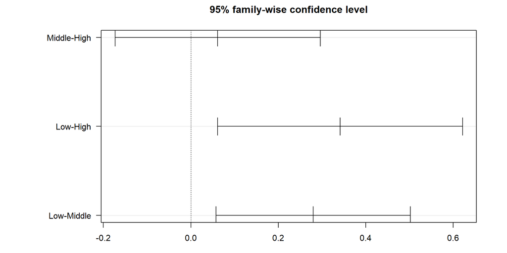

## Normality still a problem?

```r
plot(m2, which = 2)
```

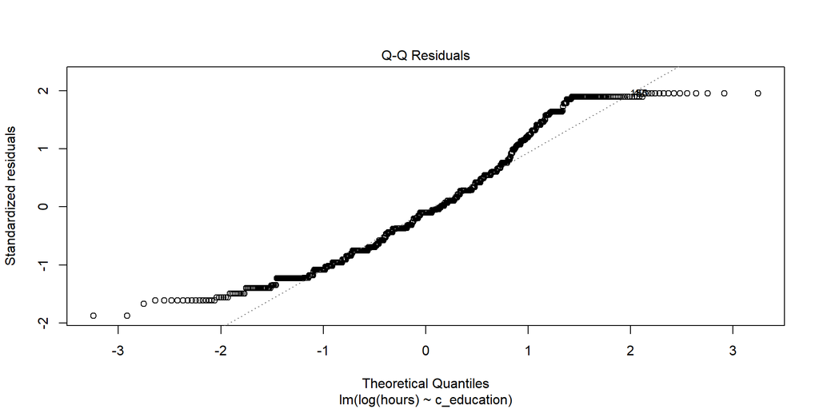

## Kruskal-Wallis ANOVA

If the data were severely skewed, you might try:

```r
kruskal.test(hours ~ c_education, data = ecare_1)
```

```
    Kruskal-Wallis rank sum test

data:  hours by c_education
Kruskal-Wallis chi-squared = 11.216, df = 2, p-value = 0.003669
```

## K Samples: Comparing Means I

1. What is the outcome under study?
2. What are the ($K \geq 2$) treatment/exposure groups?
3. Were the data in fact collected using independent samples?
4. Are the data random samples from the population(s) of interest? Or is there at least a reasonable argument for generalizing from the samples to the population(s)?
5. What confidence level do we require?

## K Samples: Comparing Means II

6. Are we doing one-sided or two-sided testing? (usually 2-sided)
7. What does the distribution of each individual sample tell us about which inferential procedure to use?
8. Are there meaningful differences between population means?
9. Can we identify pairwise comparisons of means that show meaningful differences using an appropriate procedure that protects against Type I error expansion due to multiple comparisons?

## Another ANOVA Example

- Starting on the next slide, there is a second one-factor ANOVA example (using the same EUROFAMCARE data) for self-study.
- I have edited [Section 9.9 of the Course Book](https://thomaselove.github.io/431-book/09_transmore.html#pairwise-comparisons-of-means) to reflect correct simultaneous CIs for the Bonferroni and Tukey methods as presented today.

OK, let’s return to discussing the [favorite movies](https://github.com/THOMASELOVE/431-classes-2025/tree/main/class09) data.

# A Second One-Factor ANOVA Example for Self-Study

## Same data, new question

Do `pos_impact` means differ by `dependency` level?

```r
ecare_2 <- ecare_new |> filter(complete.cases(pos_impact, dependency))

ecare_2 |> group_by(dependency) |> reframe(lovedist(pos_impact))
```

```
# A tibble: 4 × 11
  dependency      n  miss  mean    sd   med   mad   min   q25   q75   max
  <fct>       <int> <int> <dbl> <dbl> <dbl> <dbl> <dbl> <dbl> <dbl> <dbl>
1 independent    65     0  13.2  2.21    13  2.97     8    12    15    16
2 slight        224     0  12.8  2.15    13  2.97     6    12    15    16
3 moderate      303     0  12.3  2.17    12  2.97     6    11    14    16
4 severe        289     0  12.2  2.34    12  2.97     5    11    14    16
```

- Balanced design?
- Reasonable to pool standard deviations?

## Draw comparison boxplots

- Do we see serious problems with Normality?

```r
ggplot(ecare_2, aes(y = pos_impact, x = dependency)) +
  geom_violin(aes(fill = dependency)) +
  geom_boxplot(width = 0.2) +
  stat_summary(fun = mean, geom = "point",
               shape = 16, size = 3, col = "red") +
  scale_fill_viridis_d(alpha = 0.3) +
  guides(fill = "none") +
  coord_flip()
```

## Draw comparison boxplots

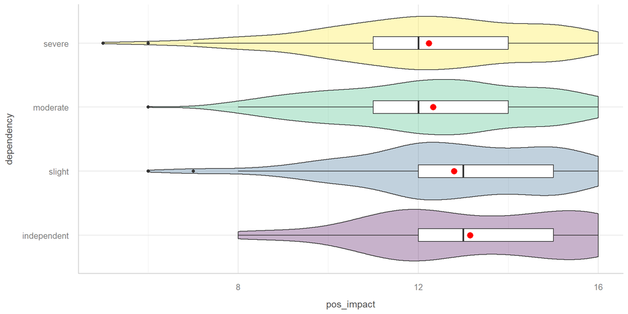

## Fit an ANOVA model

```r
m3 <- lm(pos_impact ~ dependency, data = ecare_2)
anova(m3)
```

```
Analysis of Variance Table

Response: pos_impact
            Df Sum Sq Mean Sq F value   Pr(>F)
dependency   3   76.3 25.4313  5.1255 0.001614 **
Residuals  877 4351.5  4.9618
---
Signif. codes:  0 '***' 0.001 '**' 0.01 '*' 0.05 '.' 0.1 ' ' 1
```

```r
model_parameters(m3, ci = 0.95)
```

```
Parameter             | Coefficient |   SE |         95% CI | t(877) |      p
-----------------------------------------------------------------------------
(Intercept)           |       13.15 | 0.28 | [12.61, 13.70] |  47.61 | < .001
dependency [slight]   |       -0.36 | 0.31 | [-0.98,  0.26] |  -1.14 | 0.253
dependency [moderate] |       -0.82 | 0.30 | [-1.42, -0.23] |  -2.71 | 0.007
dependency [severe]   |       -0.92 | 0.31 | [-1.52, -0.32] |  -3.02 | 0.003
```

## Simultaneous Bonferroni CIs?

```r
PostHocTest(aov(m3), method = "bonferroni", conf.level = 0.95)
```

```
  Posthoc multiple comparisons of means : Bonferroni
    95% family-wise confidence level

$dependency
                            diff     lwr.ci      upr.ci   pval
slight-independent   -0.35920330 -1.1890359  0.47062934 1.0000
moderate-independent -0.82381315 -1.6289472 -0.01867910 0.0417 *
severe-independent   -0.92201224 -1.7305835 -0.11344097 0.0159 *
moderate-slight      -0.46460985 -0.9836277  0.05440796 0.1089
severe-slight        -0.56280895 -1.0871430 -0.03847494 0.0278 *
severe-moderate      -0.09819909 -0.5824973  0.38609915 1.0000

---
Signif. codes:  0 '***' 0.001 '**' 0.01 '*' 0.05 '.' 0.1 ' ' 1
```

## Plot means with Bonferroni CIs

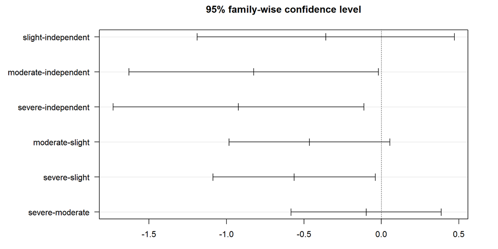

## Consider transforming `pos_impact`?

```r
boxCox(m3)
```

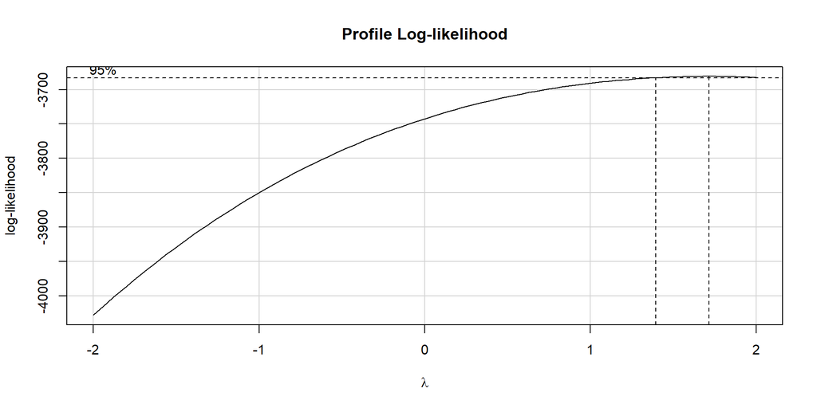

## Impact of square transformation

```r
ecare_2 |> group_by(dependency) |> reframe(lovedist((pos_impact^2)))
```

```
# A tibble: 4 × 11
  dependency      n  miss  mean    sd   med   mad   min   q25   q75   max
  <fct>       <int> <int> <dbl> <dbl> <dbl> <dbl> <dbl> <dbl> <dbl> <dbl>
1 independent    65     0  178.  56.8   169  71.2    64   144   225   256
2 slight        224     0  168.  53.0   169  71.2    36   144   225   256
3 moderate      303     0  157.  52.9   144  65.2    36   121   196   256
4 severe        289     0  155.  55.5   144  65.2    25   121   196   256
```

```r
ggplot(ecare_2, aes(y = (pos_impact^2), x = dependency)) +
  geom_violin(aes(fill = dependency)) +
  geom_boxplot(width = 0.2) +
  stat_summary(fun = mean, geom = "point",
               shape = 16, size = 3, col = "red") +
  scale_fill_viridis_d(alpha = 0.3) +
  guides(fill = "none") +
  coord_flip()
```

## Impact of square transformation

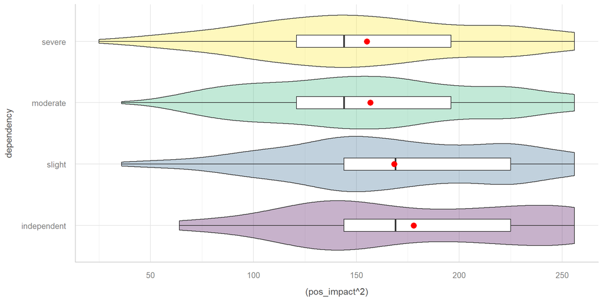

## ANOVA after Transformation

```r
m4 <- lm((pos_impact^2) ~ dependency, data = ecare_2)
anova(m4)
```

```
Analysis of Variance Table

Response: (pos_impact^2)
            Df  Sum Sq Mean Sq F value   Pr(>F)
dependency   3   45967   15322  5.2383 0.001379 **
Residuals  877 2565252    2925
---
Signif. codes:  0 '***' 0.001 '**' 0.01 '*' 0.05 '.' 0.1 ' ' 1
```

```r
model_parameters(m4, ci = 0.95)
```

```
Parameter             | Coefficient |   SE |           95% CI | t(877) |      p
-------------------------------------------------------------------------------
(Intercept)           |      177.83 | 6.71 | [164.66, 191.00] |  26.51 | < .001
dependency [slight]   |       -9.51 | 7.62 | [-24.46,   5.45] |  -1.25 | 0.212
dependency [moderate] |      -21.10 | 7.39 | [-35.61,  -6.59] |  -2.85 | 0.004
dependency [severe]   |      -22.74 | 7.42 | [-37.31,  -8.17] |  -3.06 | 0.002
```

## Simultaneous Bonferroni CIs?

```r
PostHocTest(aov(m4), method = "bonferroni", conf.level = 0.95)
```

```
  Posthoc multiple comparisons of means : Bonferroni
    95% family-wise confidence level

$dependency
                           diff    lwr.ci     upr.ci   pval
slight-independent    -9.509341 -29.65758 10.6388976 1.0000
moderate-independent -21.104697 -40.65326 -1.5561371 0.0265 *
severe-independent   -22.740804 -42.37282 -3.1087889 0.0136 *
moderate-slight      -11.595356 -24.19705  1.0063351 0.0910 .
severe-slight        -13.231463 -25.96223 -0.5006954 0.0367 *
severe-moderate       -1.636107 -13.39481 10.1225969 1.0000

---
Signif. codes:  0 '***' 0.001 '**' 0.01 '*' 0.05 '.' 0.1 ' ' 1
```

## Bonferroni 95% CIs: (`pos_impact`^2)

```r
par(mar=c(3,10,3,3), las = 1)
plot(PostHocTest(aov(m4), method = "bonferroni",
            conf.level = 0.95, ordered = TRUE))
```

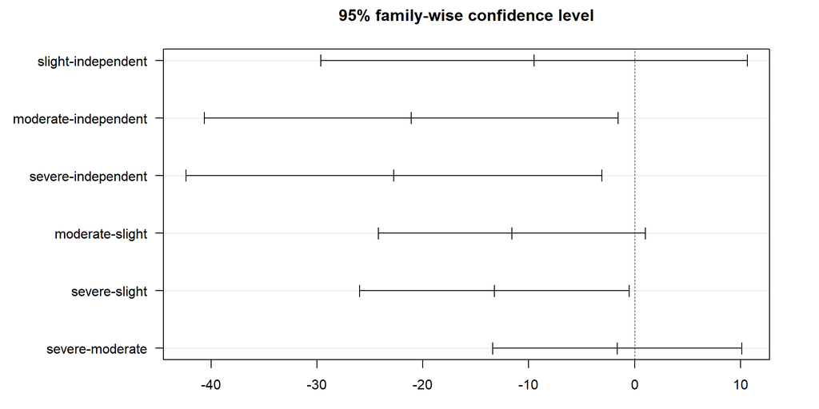